# NHL Salary Prediction

Julien Crabié

28 November 2018

Install all required packages

```r
library('randomForest')
library('plyr')
library('stringr')
library('eeptools')
```

```r
library(data.table)
library(corrplot)
library(tidyr)
library(MLmetrics)
library(MASS)
```

Load the Train, Test and Output Datasets

```r
train = read.csv("train.csv", header = TRUE, stringsAsFactors=FALSE)
test = read.csv("test.csv", header = TRUE, stringsAsFactors=FALSE)
y_test <- read.csv("test_salaries.csv", header = TRUE)
```

Check the total number of NA’s in the dataset

```r
train_sample = head(train, 20)
sum(is.na(train))
```

```
## [1] 426
```

```r
sum(is.na(test))
```

```
## [1] 103
```

Number of NA’s column wise and row wise in the train set

```r
#Number of NA's col wise
NA_df_col_num =data.frame(sapply(train, function(x) sum(is.na(x))))

#Number of NA's row wise
NA_df_row_num = data.frame(apply(train, MARGIN = 1, function(x) sum(is.na(x))))
```

Number of NA’s column wise and row wise in the test set

```r
#Number of NA's col wise
NA_df_col_test =data.frame(sapply(test, function(x) sum(is.na(x))))

#Number of NA's row wise
NA_df_row_test = data.frame(apply(test, MARGIN = 1, function(x) sum(is.na(x))))
```

Remove the entry with the most number of NA’s from the train set

```r
train<-train[!(train$First.Name=="Dan" & train$Last.Name=="Renouf"),]
```

Create a new column ‘Age’ based on the the existing ‘Born’ in the train

```r
train$Prefix = ifelse(as.numeric(substr(train$Born, start = 1, stop = 2)) <= 5, 20, 19)

train$Age = round(age_calc(as.Date(paste(train$Prefix,train$Born, sep = "")),as.Date("2016-10-01"), units = 'years'))

train$Prefix = NULL
```

Create the ‘Age’ column in the test dataset too

```r
test$Prefix = ifelse(as.numeric(substr(test$Born, start = 1, stop = 2)) <= 5, 20, 19)

test$Age = round(age_calc(as.Date(paste(test$Prefix,test$Born, sep = "")),as.Date("2016-10-01"), units = 'years'))

test$Prefix = NULL
```

Create a new column ‘Experience’ based on the first drafted year of the player. Replace the missing values in Experience, Ovrl and DrftRd columns as shown below.

```r
train$Experience = round(2017 - train$DftYr , 1)
train$Experience[is.na(train$Experience)] <- 0

train$DftRd[is.na(train$DftRd)] <- 10
train$Ovrl[is.na(train$Ovrl)] <- 0

test$Experience = round(2017 - test$DftYr , 1)
test$Experience[is.na(test$Experience)] <- 0

test$DftRd[is.na(test$DftRd)] <- 10
test$Ovrl[is.na(test$Ovrl)] <- 0
```

Manually eliminate the variables which are highly correlated to be fed into the model. Also replacing the other NA’s with the mean of their corresponding column

```r
chosen = train[, c(1,7,8,10:12,15:17,22,24:25,29,32:35,38,40,42,43,44,45,46,49,50,52,55,60,61,67,68,72,73,85:96,98:107,110,114:116,120,146,147,150:156)]


tokeep <- which(sapply(chosen,is.numeric))
train_num = chosen[ , tokeep]

# Replace NA's with mean of column
for(i in 1:ncol(train_num)){
  train_num[is.na(train_num[,i]), i] <- mean(train_num[,i], na.rm = TRUE)

}
```

Follow the same steps on the test dataset too.

```r
test_df = cbind(y_test, test)
test = test_df[, c(1,7,8,10:12,15:17,22,24:25,29,32:35,38,40,42,43,44,45,46,49,50,52,55,60,61,67,68,72,73,85:96,98:107,110,114:116,120,146,147,150:156)]


tokeep_test <- which(sapply(test,is.numeric))

test = test[ , tokeep_test]

# Replace NA's with mean of column
for(i in 1:ncol(test)){
  test[is.na(test[,i]), i] <- mean(test[,i], na.rm = TRUE)

}
```

Fine tune the variable selection by using a random forest method of feature selection.

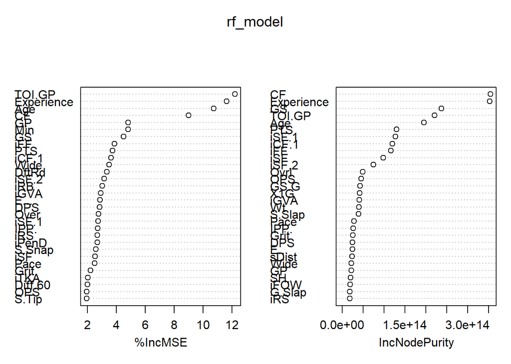

```r
# Random Forest Feature Selection

rf_model = randomForest(Salary ~ ., data=train_num, importance=TRUE, ntree=100)

importance = importance(rf_model)

varImpPlot(rf_model)
```

Sort the variables based on the decreasing order of the variable importance values obtained on running the random forest model

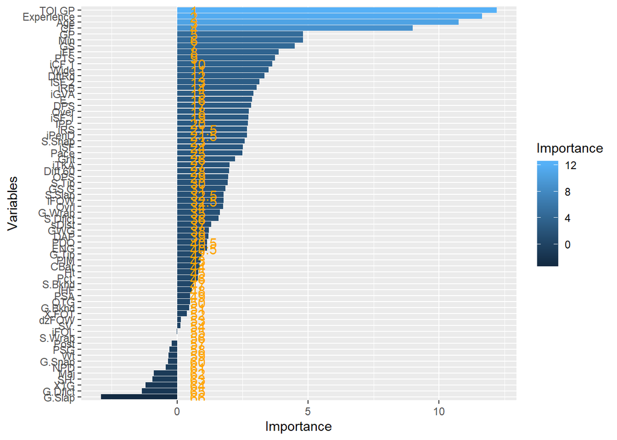

```r
varImportance = data.frame(Variables = row.names(importance),
                           Importance = round(importance[ ,'%IncMSE'],2))

#Create a rank variable based on importance
rankImportance <- varImportance %>%
  mutate(Rank = rank(desc(Importance)))

#Plot the rank to see the importance of variables clearly
ggplot(rankImportance, aes(x = reorder(Variables, Importance),
                           y = Importance, fill = Importance)) +
  geom_bar(stat='identity') +
  geom_text(aes(x = Variables, y = 0.5, label = Rank),
            hjust=0, vjust=0.55, size = 4, colour = 'orange') +
  labs(x = 'Variables') +
  coord_flip()
```

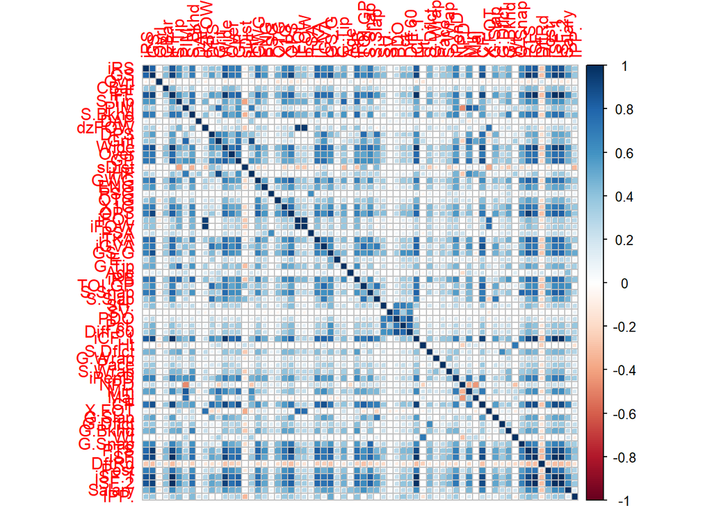

```r
imp_var = subset(rankImportance, Rank <= 70)

imp_ones = imp_var$Variables

final_df = train_num[imp_ones]
final_df$Salary = train_num$Salary

final_test = test[imp_ones]
final_test$Salary = test$Salary

cor_final = cor(final_df)
corrplot(cor_final, method = 'square')
```

```r
lm_model = lm(Salary ~ . , data = final_df)

y_pred = predict(lm_model, final_test[,-which(names(final_test) == "Salary")])

lm_model
```

```
##
## Call:
## lm(formula = Salary ~ ., data = final_df)
##
## Coefficients:
## (Intercept)          iRS           GS         Ovrl         CBar          iFF
##    -8885763       -39515       -19317        -2023       -63011       -25340
##       S.Tip          PIM       S.Bkhd          DAP        dzFOW          DPS
##       59177         7355        15877         3725       -11984         9790
##        Grit         Wide         Over           GP        sDist          iHF
##        4600        12241        63754       -55542       -11403        -2037
##         GWG          ENG          PSG          OTG          X1G          OPS
##      128227        48434       112933         8079        64388      -741777
##        iFOL         iFOW          PSA         iTKA         iGVA         GS.G
##       -1973         5817       338170       -25931         1178      1030747
##        E...        G.Tip          Age          iRB       TOI.GP       S.Snap
##       15576      -156346       174421       -17908       109272        -4304
##      S.Slap          SH.          SV.          PDO         Pct.      Diff.60
##       -4132      -150460    -13116488        19692        -1667      -202387
##       iCF.1           Ht      S.Dflct       G.Wrap         Pace       S.Wrap
##        1703       -48402         6723       339497        -5538       -83050
##       iPenD          NPD          Min          Maj           CF        X.FOT
##       -2940        -9460       -30724       -48218         1716         1360
##      G.Slap      G.Dflct       G.Bkhd           Wt       G.Snap          PTS
##       47529       101489         1185        14512        56793       112864
##         iSF        DftRd         Post        iSF.1        iSF.2         IPP.
##       38317       -74967        16931       601391      -602846        -3096
```

```r
sm = summary(lm_model)

cor(y_test$Salary, y_pred)
```

```
## [1] 0.7870331
```

```r
mean(sm$r.squared)
```

```
## [1] 0.6985202
```

Compute the RMSE for the linear model

```r
RSS = c(crossprod(lm_model$residuals))
MSE = RSS / length(lm_model$residuals)
RMSE = sqrt(MSE)
RMSE
```

```
## [1] 1227414
```

Compute the MAPE of the mulitple linear regression model

```r
MAPE(y_pred, y_test$Salary)
```

```
## [1] 0.8345729
```

Let’s try building a random forest regression model.

```r
rf_regr = randomForest(Salary ~. , data = final_df, ntree = 75 )
rf_regr
```

```
##
## Call:
##  randomForest(formula = Salary ~ ., data = final_df, ntree = 75)
##                Type of random forest: regression
##                      Number of trees: 75
## No. of variables tried at each split: 21
##
##           Mean of squared residuals: 1.981805e+12
##                     % Var explained: 60.34
```

```r
y_rf = predict(rf_regr, final_test[,-which(names(final_test) == "Salary")])
```

Compute the MAPE for the random forest model

```r
MAPE(y_rf, y_test$Salary)
```

```
## [1] 0.4835282
```

On comparing between the Mean Accuracy Percentage Error between the two regression models, we find that the random forest regression model gives us a better accuracy. This is mainly because the random forest models fits the data to the model very well.